# Not Normal: A Simulation Study Comparing Effect Sizes for Skewed Psychological Data

Ambra Perugini, Giulia Calignano, Massimiliano Pastore

```
2025-12-03
```

# 1 Introduction

Researchers often behave as if a single number could capture the entire contrast between two empirical worlds. In psychological research, standardized effect size metrics are ubiquitous. As suggested by Lakens (2013), Cohen’s d is “the most widely used effect size in psychological research” and is routinely used in meta-analyses aggregating group differences. As proposed by McGraw & Wong (1992) and Mastrich (2021), the Common Language Effect Size (CLES) is “an appealing index of effect size,” offering an intuitive interpretation in terms of probabilities of superiority. In their standard parametric form, both Cohen’s d and CLES answer to the distance between means under assumptions of smooth, symmetric, and homoscedastic distributions. Under those conditions, variance does not rebel, and tails do not bend.

Yet the distributions underlying psychological data rarely obey this ideal. Even in purely simulated scenarios, once asymmetry, variance heterogeneity, and modest or large mean shifts are introduced, the data no longer present a single clean contrast in location. Skewed distributions, heavy right tails, and unequal dispersions create conditions where the “same” effect, expressed as a standardized mean difference, may emerge from very different shapes. Metrics that compress the entire contrast into a standardized difference in means can then misrepresent how groups truly diverge: they may be accurate about a central shift while remaining blind to the structure of the tails or to the degree of overlap between distributions.

As defined by Pastore & Calcagnì (2019), the Overlapping Index (η) formalizes a distribution-sensitive perspective by quantifying how much two empirical density functions intersect. Unlike parametric overlap measures derived from Cohen’s d (such as the Overlapping Coefficient, OV), η does not rely on normality or equal variances and can register differences that live in skewness, kurtosis, or tail behavior. In this sense, Cohen’s d, CLES, OV, and η can be regarded as four different storytellers: some summarizing only where the centers lie, others attending to how far and how often the distributions diverge in their shapes.

The present work compares these four metrics that is, Cohen’s d, CLES, OV, and η across a controlled set of non-normality scenarios generated from skew-normal populations. By systematically varying mean differences, variance ratios, skewness, and sample sizes, and by computing all four indices on the same simulated datasets, we examine both how strongly they agree in practice and how well they recover the underlying population contrasts. We evaluate their behavior through Relative Mean Bias, Normalized Root Mean Square Error, and Coverage, thereby assessing not only the magnitude each index reports but also its bias, stability, and inferential reliability under violations of normality and homoscedasticity. These results reveal when classical, mean-based storytellers (d, CLES, OV) essentially retell the same narrative, and when the distribution-based η instead traces a distinct contour of difference, one grounded in how much the two distributions truly overlap rather than in how far apart their means appear.

Of notice, the simulation-based approach is useful because it allows the evaluation of effect-size indices under fully controlled conditions, where the data-generating mechanisms are explicitly known and can be manipulated independently. As emphasized in the broader methodological literature on model assessment and inference Akaike (1973); Burnham & Anderson (2002); Wagenmakers & Farrell (2004), simulation provides a principled way to examine how estimators behave when theoretical assumptions are systematically violated. By varying mean differences, variance ratios, skewness, kurtosis, and sample sizes, simulations make it possible to quantify bias, precision, and robustness in ways that real datasets that are necessarily, limited, idiosyncratic, and often confounded cannot support. This framework exposes each metric to the kinds of distributional structures that typify psychological data, revealing where classical indices remain stable and where they fail. In this sense, simulation functions as an empirical stress test, offering a clearer view of the operating characteristics of Cohen’s d, CLES, OV, and η across the proposed landscape of plausible data-generating scenarios.

# 2 The Simulation Study

## 2.1 Data Generation

The simulation generates data sets from density distributions in different scenarios. In particular, we used the Skew-Normal distribution (Azzalini, 1985), which is defined in the following way: given $\xi \in \mathbb{R}$, $\omega \in \mathbb{R}^{+}$ and $\alpha \in \mathbb{R}$, then for $y \in \mathbb{R}$ we have

$$\mathcal{SN}(y|\xi, \omega, \alpha)
= \frac{1}{\omega \sqrt{2\pi}}
\exp\left[
-\frac{1}{2}\left( \frac{y-\xi}{\omega} \right)^2
\right]
\left[
1 + \text{erf}\left(
\alpha \left( \frac{y-\xi}{\omega\sqrt{2}} \right)
\right)
\right]
\tag{1}$$

in which

$$\text{erf}(z)
= \frac{2}{\sqrt{\pi}} \int_{0}^{z} e^{-t^2}\, dt
\tag{2}$$

is the *error function*.

$\xi$ is the location parameter, $\omega$ is the scale parameter and $\alpha$ is related to the skewness of the distribution. The case in which $\xi = 0$, $\omega = 1$ and $\alpha = 0$ corresponds to the standard normal distribution. This distribution has been chosen to generate the data as it allows to model both the distance between means (the effect size), symmetry and variance. Consequently, it is optimal for our purpose as it allows us to have control over the parameters of mean, variance, skewness and kurtosis.

Mean and variance of the Skew-Normal are respectively:

$$\begin{aligned}
\mu &= \xi + \omega \gamma \sqrt{2/\pi} \\
\sigma^2 &= \omega^2 \left[1 - \frac{2\gamma^2}{\pi}\right]
\end{aligned}
\tag{3}$$

in which $\gamma = \alpha / \sqrt{1 + \alpha^2}$.

Based on Equation 3 we can determine the values to assign to the parameters $\xi$ and $\omega$ as functions of $\mu$ and $\sigma$ with:

$$\begin{aligned}
\xi &= \mu - \omega \gamma \sqrt{2/\pi} \\
\omega &= \sqrt{\frac{\sigma^2}{1 - (2\gamma^2)/\pi}}
\end{aligned}
\tag{4}$$

## 2.2 Simulation design

The experiment consists of comparing two samples. We generated the first sample from $\mathcal{SN}(0,1,0)$, which corresponds to a Standard Normal distribution with mean 0 and variance 1. We generated the second sample from $\mathcal{SN}(\xi,\omega,\alpha)$, where the parameters are manipulated to produce specific differences in means ($\delta$), standard deviations ($\sigma$), and skewness ($\alpha$) between the two populations.

Overall, the experimental design comprises 8 scenarios. In each scenario, the first sample remains fixed as $\mathcal{SN}(0,1,0) \equiv N(0,1)$, while the second sample is defined by the following parameter settings:

- $\mu_2$ = 0, 2; mean of the second population. As the first sample always comes from a population with a mean of 0, this parameter — the mean of the population from which the second sample is drawn — also represents the true difference between the means. Consequently, in the following sections of the paper we refers to this parameter as $\delta$ ;
- $\sigma$ = 1, 5; standard deviation of the second population;
- $\alpha$ = 0, 10; asymmetry varies in the second group;
- $n$ = 10, 50, 100, 300, 500, 1000; sample size, equal in the two samples.

Figure 1 displays the experimental scenarios: the black curves correspond to the first population, consistently modeled as $\mathcal{SN}(0,1,0) \equiv N(0,1)$, whereas the red curves represent the second population $\mathcal{SN}(\xi,\omega,\alpha)$. The vertical dashed lines indicate the means of these second distributions and also the mean difference, $\delta$.

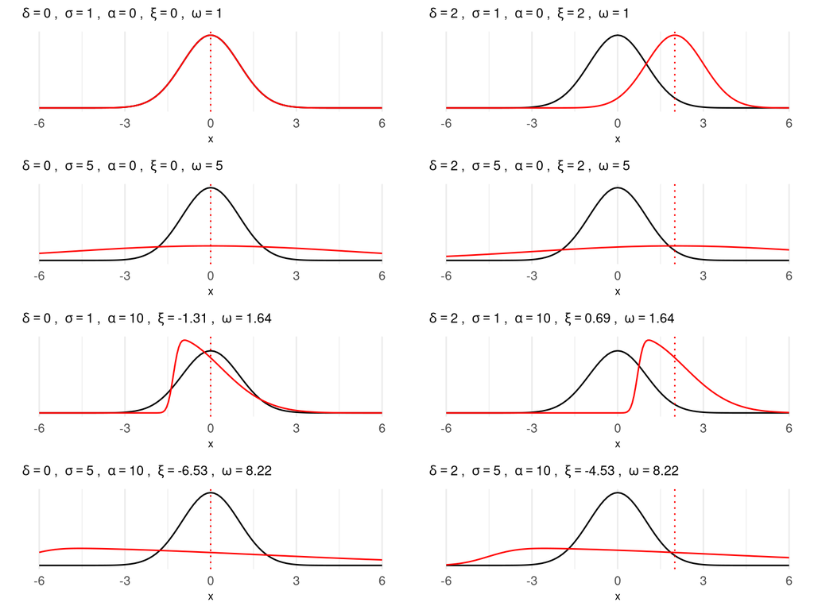

Figure 1: Representation of the simulation. In each panel, the black curves correspond to the first population $\mathcal{SN}(0,1,0) \equiv N(0,1)$, while the red curves correspond to the second population $\mathcal{SN}(\xi,\omega,\alpha)$.

For each of the 8 conditions we generated 2000 couples of independent samples and performed the analysis. On these generated data, for each combination $\delta\times\sigma\times\alpha\times n$, we computed the following effect sizes:

- Cohen’s $d$
- Common Language Effect Size (CLES).
- Two kinds of Overlapping Coefficient:
  1. *Parametric* ($\eta_p$)
  2. *Non-parametric* ($\eta$).

## 2.3 Definition of Effect sizes

### 2.3.1 Cohen’s d:

The Cohen’s $d$ is an effect size that standardizes differences in means between groups or conditions (Cohen, 1988). This index theoretically ranges from 0 to $+\infty$ (for differences in one direction) or $-\infty$ to 0 (for the opposite direction), but in practice, values rarely exceed a range of -3 to +3. A value of 0 indicates identical group means, whereas larger absolute values indicate greater centroid distance. In the simulated scenarios, it is appropriate to apply the between groups formula:

$$d = \frac{\bar{X}_1 - \bar{X}_2}{s_p}
\tag{5}$$

where ${s_p}$ is the pooled standard deviation defined as $s_p = \sqrt{\frac{(n_1 - 1)s_1^{2} + (n_2 - 1)s_2^{2}}{n_1 + n_2 - 2}}$.

### 2.3.2 Common Language Effect Size (CLES):

CLES represents the probability that a randomly picked individual from the group with the higher mean will exceed a randomly picked individual from the other group (McGraw & Wong, 1992). This index ranges from 0 to 1 and expresses the probability that a randomly selected observation from one group will exceed a randomly selected observation from another. A value of 0.50 indicates complete overlap (no effect), values above 0.50 favor one group, and values below 0.50 favor the other, and calculated from data the formula is:

$$CL = \frac{N_1}{N_1+N_0}
\tag{6}$$

in which $N_1$ indicates the number of ordered pairs in which the first observation is greater than the second, and $N_0$ the number of ordered pairs in which the first observation is smaller than the second.

It can be also calculated as a function of Cohen’s $d$, $\Phi$ is the normal cumulative distribution function:

$$CL = \Phi(|d|/\sqrt{2})
\tag{7}$$

### 2.3.3 Overlapping Coefficient:

The concept of overlap refers to the shared area between two or more probability density functions. It provides an intuitive measure for assessing the degree of similarity or difference between samples or populations characterized by their distributions. When two populations (or samples) exhibit a high degree of overlap in their distribution functions, it suggests a strong similarity between them. Conversely, minimal overlap indicates substantial differences.

The *parametric* version of the Overlapping coefficient can be derived from Cohen’s $d$ as follows:

$$\eta_p = 2\Phi(-|d|/2)
\tag{8}$$
where $\Phi$ is the normal cumulative distribution function.

The *non-parametric* version ($\eta$) is computed using a kernel approach and serves as a distribution-free approximation of $\eta_p$ (for more details, see Pastore & Calcagnì (2019)).

This coefficient varies from zero (indicating complete disjointness) to one (indicating complete overlap) and can be considered an index of similarity between groups or conditions.

## 2.4 Performance Indexes for comparison

In order to compare the performance of the chosen indices, we need indices that are not related to possible empirical values. We should note that, whereas Cohen’s $d$ ranges over the real numbers, the other three indices range from 0 to 1. Consequently, we used the following performance indices:

- *Relative mean bias* (RMB) captures the average proportional deviation between an estimator and its population value across Monte Carlo replications. It is defined as
  $$RMB = (1/B) \sum_b \left[ (\hat{\theta}_{bj} − \theta_j) / \theta_j \right].$$
  where $\theta_j$ is the true parameter value in condition $j$ and $\hat{\theta}_{bj}$ is the estimated value in the $b$ replications for condition $j$. Because this ratio expresses error relative to the magnitude of the true parameter, it produces a scale-free measure of systematic distortion. Values close to zero indicate negligible bias, and values within the $\pm 0.10$ interval are typically interpreted as acceptable. Whenever the true value $\theta_j$ equals zero, a small constant $(\epsilon = 10^-6)$ is substituted to prevent undefined divisions, ensuring numerical stability across replications.
- *Normalized root mean square error* (NRMSE) extends this scale-free approach to overall estimation error. It is simply derived from the Root Mean Square Error (RMSE) index dividing it by the empirical range of observed estimates,
  $$NRMSE = RMSE / (max(obs) − min(obs)),$$
  As with RMB, lower values indicate better performance.
- *Coverage* evaluates whether the inferential procedure is properly calibrated. It represents the proportion of simulated datasets whose 90% confidence interval contains the true parameter value. High coverage indicates that the interval estimation procedure maintains its nominal reliability, independent of the scale of the underlying effect-size index.

Note that, other traditional indices such as Absolute Mean Bias, Mean Square Error, and RMSE are less suitable in this context because they remain scale-dependent. The relative and normalized metrics above resolve this limitation by expressing accuracy on a common proportional scale.

# 3 Results

## 3.1 Descriptive statistics

In Figure 2 reports the pairwise correlations among the four effect size indices considered in the study (Cohen’s $d$, CLES, $\eta_p$, and $\eta$) across all 48 simulated conditions. The diagonal panels display the univariate distribution of each index, whereas the off-diagonal panels present the scatter plot (under the diagonal) and pairwise correlation coefficients (above the diagonal); different colors represent different sample sizes (n = 10, 50, 100, 300, 500, 1000).

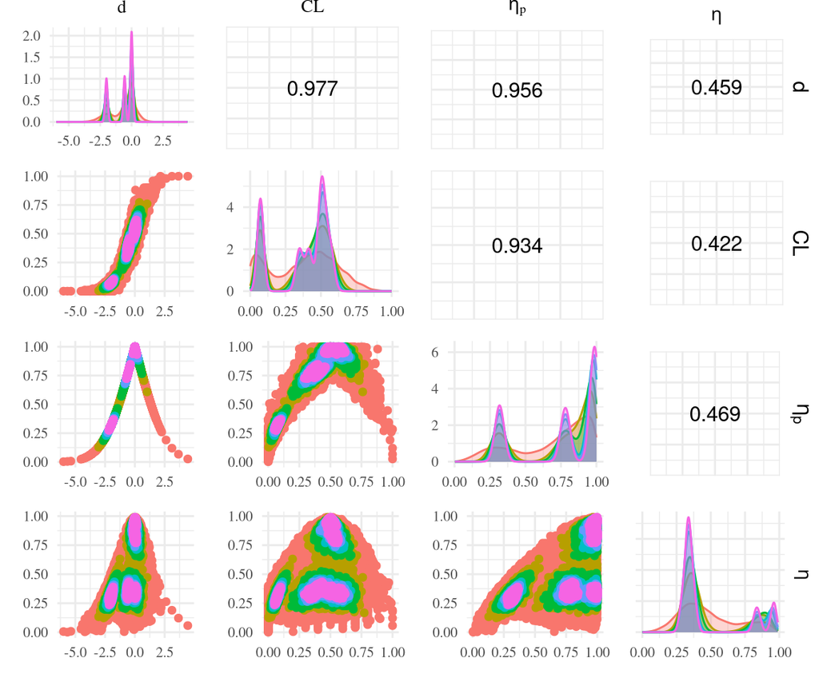

Figure 2: Pairwise relationship between indexes. The diagonal panels show the distribution of each index individually, while the off-diagonal panels show the scatter plot (below the diagonal) and the correlation coefficients (above the diagonal). Different colours represent different sample sizes.

## 3.2 Performance Indexes

To evaluate the performance of the four effect sizes, we examined their Relative Mean Bias (RMB), Normalized Root Mean Square Error (NRMSE), and Coverage across all simulated scenarios.

### 3.2.1 Relative Mean Bias (RMB)

Figure 3 shows the RMB for each index as a function of sample size and under different experimental conditions. Overall, $\eta$ and Cohen’s $d$ display the lowest bias, with values consistently close to zero across all conditions. CLES also exhibits relatively low bias across scenarios with equal means, but shows biased estimates when there is difference in means. In the opposite way, OV shows unbiased estimates under same variance ($\sigma = 1$) and biased estimates when variance is non-homogeneous between the two groups ($\sigma = 5$).

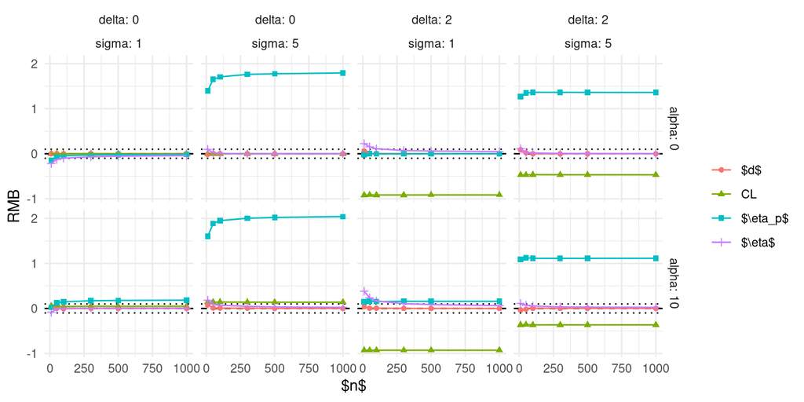

Figure 3: Relative mean bias as a function of the experimental conditions.

### 3.2.2 Normalized Root Mean Square Error

The NRMSE results (Figure 4) show that CLES displays much larger NRMSE, dominating the scale of the plot and confirming its poorer performance in terms of stability and precision when the there are differences in means between the two groups.

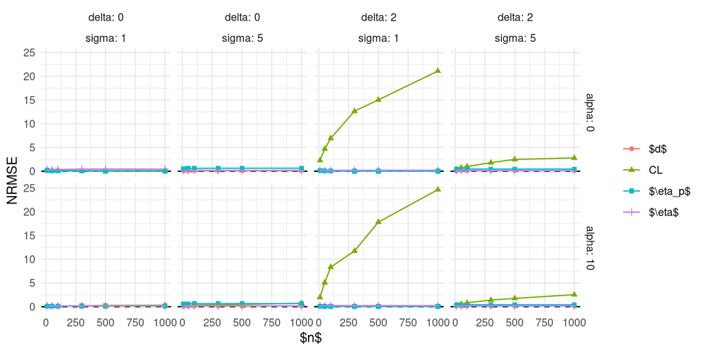

Figure 4: Normalized relative mean square error as a function of the experimental conditions.

For this reason, we also include a second plot (Figure 5) in which CLES is excluded, as its performance is considerably worse than that of the other indexes.

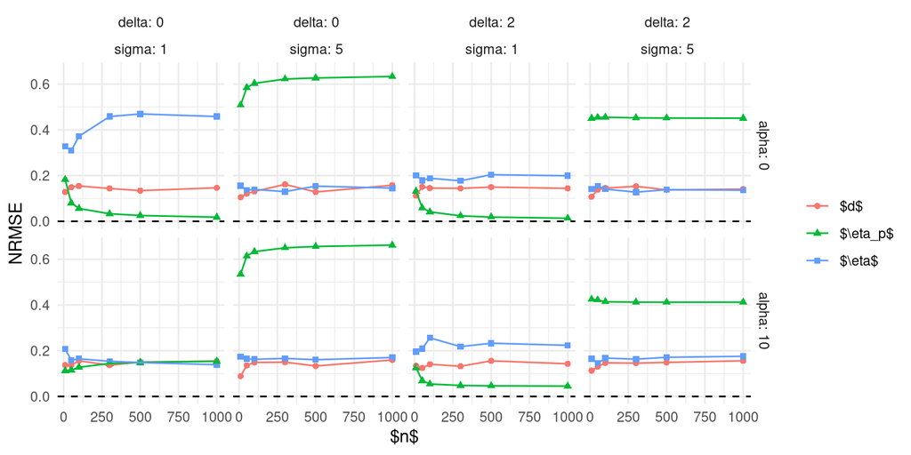

Figure 5: Normalized relative mean square error (without CLES) as a function of the experimental conditions.

### 3.2.3 Coverage

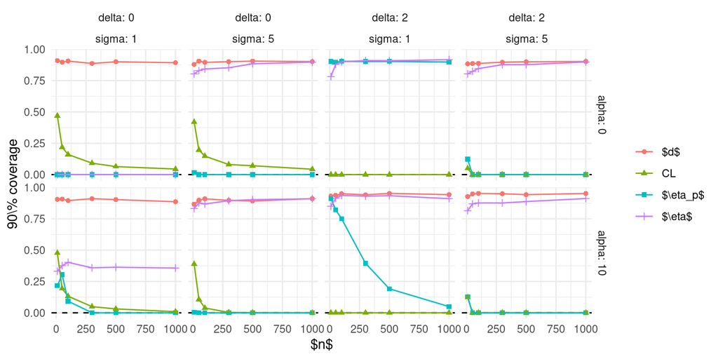

Figure 6: Coverage 90% as a function of the experimental conditions.

# 4 Discussion

The simulation results demonstrate that the four effect-size indices that is, Cohen’s d, the Common Language Effect Size (CLES), the parametric Overlapping derived from d ($\eta_p$), and the distribution-free Overlapping Index η do not constitute interchangeable descriptions of group or condition differences when distributions deviate from normality. Across all manipulated conditions (mean differences, variance ratios, skewness, and sample sizes), the indices separate into two functional families: mean-based location estimators (d, CLES, OV) and a distribution-sensitive overlap estimator (η). This separation reflects that the indices derived from d inherit all of its parametric assumptions, as suggested by Peng & Chen (2014).

These findings are especially relevant in Cognitive Psychology and Neuropsychology, where reaction-time (RT) distributions are typically right-skewed and long-tailed. In such datasets, $d$ may be a meaningful effect size even when substantial portions of distributions do not overlap. Still, it tells only part of the story, overlooking shape characteristics preserved by η characteristics that can also bear interpretable functional significance in cognitive and neuropsychological frameworks. This empirical structure has been repeatedly observed in memory and attention studies, as illustrated by Osmon (2018). Under these conditions, critically using bot $d$ and η provides a more realistic quantification of divergence, isolating distributional differences that mean-based indices obscure.

A similar principle applies in clinical psychology, where symptom distributions are rarely normal (Rubio-Aparicio et al. (2018)), and both floor effects in non-clinical populations and heavy right tails in clinical ones are common characteristics of symptom data (Haqiqatkhah et al. (2023)). These asymmetries inflate pooled variance, leading traditional effect size measures such as Cohen’s d and Common Language Effect Size (CLES) to underestimate the true separations between groups when distributions deviate from normality (Sun & Cheung (2020)).

Here, η enters not as a rival, but as a companion.Where $d$ fixes its gaze upon the center, η listens to the contour to the way distributions overlap, diverge, and rejoin across the span of shape variation (Hedges & Olkin (2016)). In doing so, it restores something that $d$ leaves silent: the shape of difference. Their relationship is not one of substitution but of complementarity as two instruments, distinct in tone yet tuned to the same melody.

In practical use, η relies on kernel-based density estimation, which smooths fluctuations and mitigates outliers (Chen et al. (2021)). Importantly, the overlapping package permits adjustment of the kernel function, introducing a controllable dimension of flexibility, what might be called a tailored robustness check, that allows η to adapt to diverse data structures. $d$, conversely, anchors interpretation in the mean, ensuring stability and comparability. Their combination provides a balanced framework for inference (Hanel & Mehler (2019)).

Thus, the lesson is not that one index should prevail, but that both deserve to speak. $d$ translates difference into the language of averages; η translates it into that of form. And somewhere between those two dialects between what is measured and what is experienced lies the truer inference, the quiet understanding that every distribution in psychology, like every life, bends a little away from symmetry.

# 5 Conclusion

The simulation approach comparing effect size indeces employed here follows established methodological frameworks advocating controlled assumption violations to evaluate estimator performance (Zhao et al. (2020)). The core emphasis of the present study here, is that no single effect-size metric suffices; robust interpretation depends on viewing several indices together and anchoring them to the shape and structure of the observed data. Simulation offers what empirical data cannot: a controlled environment for systematic stress testing. At the same time, it reflects the very distortions that shape real-world evidence, allowing us to understand how psychological effect-size indices hold or fail under those pressures.

# 6 References

Akaike, H. (1973). Information theory and an extension of the maximum likelihood principle. In B. N. Petrov & F. Csaki (Eds.), *Second International Symposium on Information Theory* (pp. 267–281).

Azzalini, A. (1985). A class of distributions which includes the normal ones. *Scandinavian Journal of Statistics*, 171–178.

Burnham, K. P., & Anderson, D. R. (2002). *Model Selection and Multimodel Inference: A Practical Information-Theoretic Approach* (2nd ed.). Springer Science & Business Media.

Chen, X., Trafimow, D., Wang, T., Tong, T., & Wang, C. (2021). The APP Procedure for Estimating the Cohen’s Effect Size. *Asian Journal of Economics and Banking*.

Cohen, J. (1988). *Statistical power analysis for the behavioral sciences* (2nd ed.). Lawrence Erlbaum Associates, Hillsdale, NJ.

Grice, J., & Barrett, P. (2014). A Note on Cohen’s Overlapping Proportions of Normal Distributions. *Psychological Reports*, *115*, 741–747.

Hanel, P., & Mehler, D. (2019). Beyond Reporting Statistical Significance: Identifying Informative Effect Sizes to Improve Scientific Communication. *Public Understanding of Science*, *28*, 468–485.

Haqiqatkhah, M. M., Ryan, O., & Hamaker, E. (2023). Skewness and Staging: Does the Floor Effect Induce Bias in Multilevel AR(1) Models? *Multivariate Behavioral Research*, *59*, 289–319. https://doi.org/10.1080/00273171.2023.2254769

Hedges, L., & Olkin, I. (2016). Overlap between treatment and control distributions as an effect size measure in experiments. *Psychological Methods*, *21*(1), 61–68. https://doi.org/10.1037/met0000042

Lakens, D. (2013). Calculating and reporting effect sizes to facilitate cumulative science: A practical primer for t-tests and ANOVAs. *Frontiers in Psychology*, *4*, 863. https://doi.org/10.3389/fpsyg.2013.00863

Mastrich, Z. (2021). A review of common language effect size indicators to facilitate research interpretability. *Frontiers in Psychology*. https://doi.org/10.3389/fpsyg.2021.648770

McGraw, K. O., & Wong, S. P. (1992). A common language effect size statistic. *Psychological Bulletin*, *111*(2), 361–365. https://doi.org/10.1037/0033-2909.111.2.361

Osmon, K., D. C. (2018). Non-Gaussian distributional analyses of reaction times (RT): Improvements that increase efficacy of RT tasks for describing cognitive processes. *Neuropsychology Review*, *28*, 359–376.

Pastore, M., & Calcagnì, A. (2019). Measuring distribution similarities between samples: A distribution-free overlapping index. *Frontiers in Psychology*, *10*, 1089. https://doi.org/10.3389/fpsyg.2019.01089

Peng, C. Y., & Chen, L. T. (2014). Beyond Cohen’s d: Alternative Effect Size Measures for Between-Subject Designs. *The Journal of Experimental Education*, *82*, 22–50.

Rubio-Aparicio, M., Marín-Martínez, F., Sánchez-Meca, J., & López-López, J. (2018). A methodological review of meta-analyses of the effectiveness of clinical psychology treatments. *Behavior Research Methods*, *50*, 2057–2073. https://doi.org/10.3758/s13428-017-0973-8

Skidmore, S. T., & Thompson, B. (2013). Bias and Precision of Some Classical ANOVA Effect Sizes When Assumptions Are Violated. *Behavior Research Methods*, *45*, 536–546.

Sun, R., & Cheung, S. (2020). The influence of nonnormality from primary studies on the standardized mean difference in meta-analysis. *Behavior Research Methods*, 1–16. https://doi.org/10.3758/s13428-019-01334-x

Wagenmakers, E.-J., & Farrell, S. (2004). AIC model selection using Akaike weights. *Psychonomic Bulletin & Review*, *11*(1), 192–196.

Wang, C., Wang, T., Chen, X., Trafimow, D., Tong, T., Hu, L., & Choy, S. T. B. (2023). The a Priori Procedure for Estimating the Cohen’s Effect Size Under Independent Skew Normal Settings. In *Advances in Statistical Theory and Applications* (pp. 111–122).

Zhao, J., Sim, S., & Kim, H.-M. (2020). Statistical Inference of Some Effect Sizes. *Journal of the Korean Statistical Society*, *49*, 976–1007.